# SHRS Competitor Analysis - Competitor Identification Report

SHRS MQE Capstone Team

2026-03-05

# 0 - About This Report

This report reads the CSVs produced by `competitor_01_pull.R` and presents the competitor landscape for all 9 SHRS programs. No API calls are made here.

```r
library(tidyverse)
library(scales)
library(kableExtra)
```

```r
# -- EDIT THIS PATH if your CSVs are in a different location --
DATA_DIR <- "competitor_data"

tier1          <- read_csv(file.path(DATA_DIR, "tier1_statewide.csv"), show_col_types = FALSE)
tier2          <- read_csv(file.path(DATA_DIR, "tier2_regional.csv"), show_col_types = FALSE)
tier1_summary  <- read_csv(file.path(DATA_DIR, "tier1_summary.csv"), show_col_types = FALSE)
tier2_summary  <- read_csv(file.path(DATA_DIR, "tier2_summary.csv"), show_col_types = FALSE)
master_roster  <- read_csv(file.path(DATA_DIR, "master_roster.csv"), show_col_types = FALSE)
pitt_rank      <- read_csv(file.path(DATA_DIR, "pitt_rank.csv"), show_col_types = FALSE)
cip_crosswalk  <- read_csv(file.path(DATA_DIR, "cip_crosswalk.csv"), show_col_types = FALSE)

PITT_UNITID <- 215293L
latest_year <- max(tier1$year, na.rm = TRUE)
if (is.na(latest_year) || is.infinite(latest_year)) {
  latest_year <- 2022
}

cat("Data loaded from:", DATA_DIR, "\n")
```

```
## Data loaded from: competitor_data
```

```r
cat("Programs:", paste(sort(unique(tier1$shrs_program)), collapse = ", "), "\n")
```

```
## Programs: AT, AuD, DN, DPT, HIM, OTD, PAS, SLP, SS
```

```r
cat("Tier 1 rows:", nrow(tier1), "| Tier 2 rows:", nrow(tier2), "\n")
```

```
## Tier 1 rows: 152 | Tier 2 rows: 47
```

# 1 - Tier 1: Statewide Competition (All PA)

How many PA institutions compete with Pitt in each program, and what is Pitt’s share of statewide graduate production?

## 1.1 Summary

```r
tier1_summary |>
  arrange(desc(total_pa_graduates)) |>
  select(
    Program          = shrs_program,
    Dept             = shrs_dept,
    `PA Schools`     = n_competitors,
    `Competitors`    = n_competitors_excl,
    `Total PA Grads` = total_pa_graduates,
    `Pitt Grads`     = pitt_graduates,
    `Pitt Share (%)`  = pitt_share_pct
  ) |>
  kable(format.args = list(big.mark = ",")) |>
  kable_styling(bootstrap_options = c("striped", "hover"), full_width = FALSE)
```

| Program | Dept | PA Schools | Competitors | Total PA Grads | Pitt Grads | Pitt Share (%) |
| --- | --- | --- | --- | --- | --- | --- |
| PAS | PAS | 21 | 20 | 5,380 | 240 | 4.5 |
| DPT | RST | 20 | 19 | 4,932 | 272 | 5.5 |
| SS | SMN | 34 | 33 | 4,436 | 164 | 3.7 |
| OTD | RST | 18 | 17 | 4,372 | 256 | 5.9 |
| SLP | CSD | 16 | 15 | 3,944 | 500 | 12.7 |
| AuD | CSD | 8 | 7 | 2,336 | 500 | 21.4 |
| AT | SMN | 22 | 22 | 1,056 | 0 | 0.0 |
| DN | SMN | 7 | 7 | 692 | 0 | 0.0 |
| HIM | HIM | 6 | 5 | 132 | 8 | 6.1 |

## 1.2 Pitt’s Share Visualization

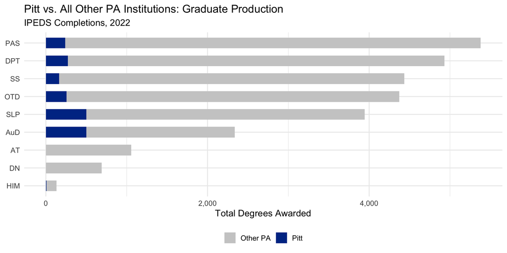

```r
tier1_summary |>
  mutate(other_graduates = total_pa_graduates - pitt_graduates) |>
  select(shrs_program, Pitt = pitt_graduates, `Other PA` = other_graduates) |>
  pivot_longer(-shrs_program, names_to = "source", values_to = "grads") |>
  ggplot(aes(x = reorder(shrs_program, grads, sum), y = grads, fill = source)) +
  geom_col(width = 0.6) +
  coord_flip() +
  scale_y_continuous(labels = comma) +
  scale_fill_manual(values = c("Pitt" = "#003594", "Other PA" = "#CCCCCC")) +
  labs(
    title = "Pitt vs. All Other PA Institutions: Graduate Production",
    subtitle = paste0("IPEDS Completions, ", latest_year),
    x = NULL, y = "Total Degrees Awarded", fill = NULL
  ) +
  theme_minimal(base_size = 13) +
  theme(legend.position = "bottom")
```

## 1.3 Pitt’s Rank in PA

```r
pitt_rank |>
  arrange(rank) |>
  select(
    Program     = shrs_program,
    `Pitt Awards` = total_awards,
    `Rank in PA`  = rank,
    `of N Schools` = n_schools,
    Percentile    = percentile
  ) |>
  kable() |>
  kable_styling(bootstrap_options = c("striped", "hover"), full_width = FALSE)
```

| Program | Pitt Awards | Rank in PA | of N Schools | Percentile |
| --- | --- | --- | --- | --- |
| AuD | 500 | 1 | 8 | 100 |
| SLP | 500 | 2 | 16 | 94 |
| DPT | 272 | 5 | 20 | 80 |
| HIM | 8 | 6 | 6 | 17 |
| OTD | 256 | 7 | 18 | 67 |
| SS | 164 | 9 | 34 | 76 |
| PAS | 240 | 12 | 21 | 48 |

## 1.4 Full Competitor Lists by Program

```r
for (prog in sort(unique(tier1$shrs_program))) {

  cat(paste0("\n### ", prog, "\n\n"))

  prog_data <- tier1 |>
    filter(shrs_program == prog) |>
    mutate(is_pitt = unitid == PITT_UNITID)

  # Table
  prog_data |>
    mutate(Institution = if_else(is_pitt, paste0("**", inst_name, " (PITT)**"), inst_name)) |>
    select(Institution, City = city, Awards = total_awards, `Degree Levels` = degree_levels) |>
    kable(format.args = list(big.mark = ",")) |>
    kable_styling(bootstrap_options = c("striped", "hover"), full_width = FALSE) |>
    print()

  # Chart
  p <- prog_data |>
    ggplot(aes(x = reorder(inst_name, total_awards), y = total_awards, fill = is_pitt)) +
    geom_col(width = 0.6) +
    coord_flip() +
    scale_fill_manual(values = c("FALSE" = "#CCCCCC", "TRUE" = "#003594"),
                      labels = c("Competitor", "Pitt"), guide = "none") +
    scale_y_continuous(labels = comma) +
    labs(title = paste0(prog, ": PA Competitor Landscape"),
         x = NULL, y = "Degrees Awarded") +
    theme_minimal(base_size = 11)
  print(p)

  cat("\n\n")
}
```

### AT

| Institution | City | Awards | Degree Levels |
| --- | --- | --- | --- |
| East Stroudsburg University of Pennsylvania | East Stroudsburg | 260 | Doctorate, Masters |
| West Chester University of Pennsylvania | West Chester | 148 | Doctorate, Masters |
| Temple University | Philadelphia | 96 | Doctorate |
| Pennsylvania State University-Main Campus | University Park | 60 | Masters |
| Moravian University | Bethlehem | 56 | Doctorate |
| Slippery Rock University of Pennsylvania | Slippery Rock | 44 | Doctorate |
| Waynesburg University | Waynesburg | 44 | Doctorate, Masters |
| Commonwealth University of Pennsylvania | Bloomsburg | 40 | Doctorate |
| Mercyhurst University | Erie | 36 | Masters |
| King’s College | Wilkes-Barre | 32 | Doctorate, Masters |
| Lebanon Valley College | Annville | 32 | Doctorate |
| Thomas Jefferson University | Philadelphia | 32 | Doctorate |
| Alvernia University | Reading | 28 | Doctorate |
| Duquesne University | Pittsburgh | 28 | Masters |
| Gannon University | Erie | 28 | Doctorate |
| Messiah University | Mechanicsburg | 28 | Masters |
| Chatham University | Pittsburgh | 16 | Doctorate |
| Pennsylvania Western University | California | 16 | Doctorate |
| University of Pittsburgh-Bradford | Bradford | 12 | Masters |
| Clarks Summit University | Clarks Summit | 8 | Masters |
| Marywood University | Scranton | 8 | Masters |
| Neumann University | Aston | 4 | Doctorate |

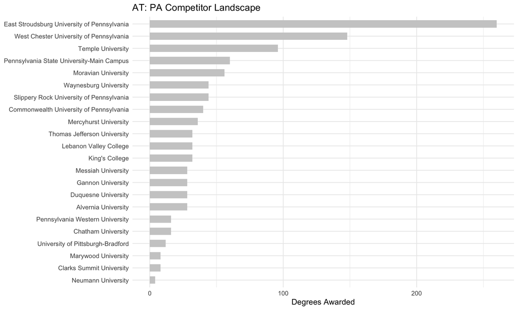

### AuD

| Institution | City | Awards | Degree Levels |
| --- | --- | --- | --- |
| **University of Pittsburgh-Pittsburgh Campus (PITT)** | Pittsburgh | 500 | Doctorate, Masters |
| West Chester University of Pennsylvania | West Chester | 452 | Doctorate, Masters |
| Temple University | Philadelphia | 428 | Doctorate, Masters |
| Commonwealth University of Pennsylvania | Bloomsburg | 292 | Doctorate, Masters |
| Salus University | Elkins Park | 232 | Doctorate |
| Indiana University of Pennsylvania-Main Campus | Indiana | 204 | Doctorate, Masters |
| Marywood University | Scranton | 176 | Doctorate, Masters |
| Thiel College | Greenville | 52 | Doctorate |

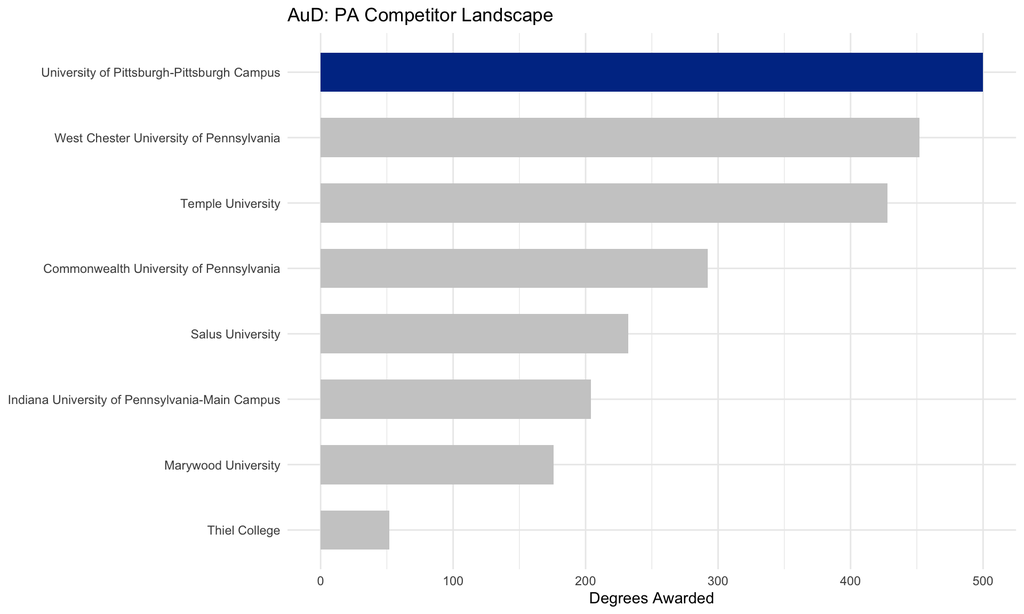

### DN

| Institution | City | Awards | Degree Levels |
| --- | --- | --- | --- |
| West Chester University of Pennsylvania | West Chester | 384 | Masters, Post-Masters Certificate |
| Cedar Crest College | Allentown | 108 | Post-Masters Certificate |
| Messiah University | Mechanicsburg | 72 | Masters, Post-Masters Certificate |
| Drexel University | Philadelphia | 52 | Doctorate |
| Marywood University | Scranton | 48 | Masters |
| Immaculata University | Immaculata | 16 | Masters |
| Seton Hill University | Greensburg | 12 | Masters |

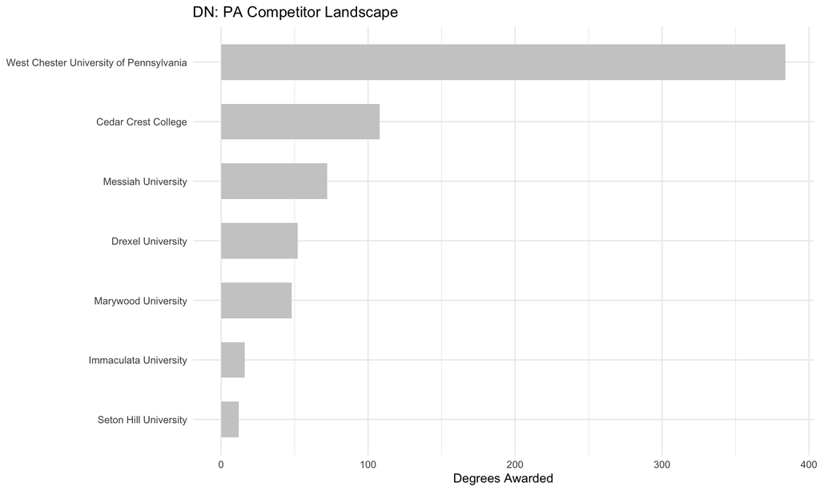

### DPT

| Institution | City | Awards | Degree Levels |
| --- | --- | --- | --- |
| Arcadia University | Glenside | 1,052 | Doctorate, Post-Masters Certificate |
| Duquesne University | Pittsburgh | 368 | Doctorate, Masters |
| Gannon University | Erie | 308 | Doctorate |
| University of Scranton | Scranton | 280 | Doctorate |
| **University of Pittsburgh-Pittsburgh Campus (PITT)** | Pittsburgh | 272 | Doctorate |
| Saint Joseph’s University | Philadelphia | 260 | Doctorate |
| Drexel University | Philadelphia | 248 | Doctorate |
| Thomas Jefferson University | Philadelphia | 244 | Doctorate |
| Slippery Rock University of Pennsylvania | Slippery Rock | 192 | Doctorate |
| Temple University | Philadelphia | 192 | Doctorate |
| Lebanon Valley College | Annville | 188 | Doctorate |
| Misericordia University | Dallas | 188 | Doctorate |
| Chatham University | Pittsburgh | 180 | Doctorate |
| Widener University | Chester | 172 | Doctorate |
| Philadelphia College of Osteopathic Medicine | Philadelphia | 160 | Doctorate |
| Saint Francis University | Loretto | 156 | Doctorate, Masters |
| Messiah University | Mechanicsburg | 144 | Doctorate |
| Neumann University | Aston | 124 | Doctorate |
| DeSales University | Center Valley | 108 | Doctorate |
| Alvernia University | Reading | 96 | Doctorate |

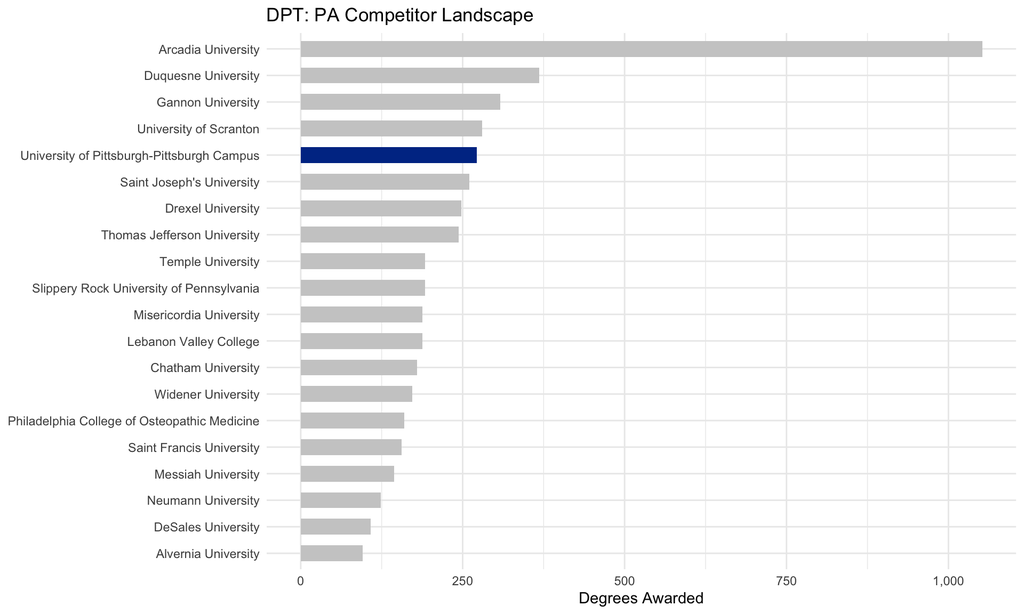

### HIM

| Institution | City | Awards | Degree Levels |
| --- | --- | --- | --- |
| Pennsylvania College of Technology | Williamsport | 40 | Masters |
| Carlow University | Pittsburgh | 28 | Masters |
| Slippery Rock University of Pennsylvania | Slippery Rock | 24 | Doctorate |
| Duquesne University | Pittsburgh | 20 | Masters |
| Peirce College | Philadelphia | 12 | Masters |
| **University of Pittsburgh-Pittsburgh Campus (PITT)** | Pittsburgh | 8 | Masters |

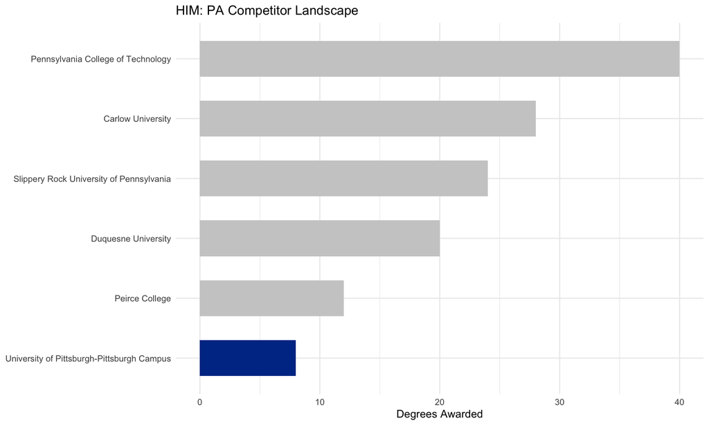

### OTD

| Institution | City | Awards | Degree Levels |
| --- | --- | --- | --- |
| Thomas Jefferson University | Philadelphia | 564 | Doctorate, Masters, Post-Masters Certificate |
| Gannon University | Erie | 392 | Doctorate |
| Alvernia University | Reading | 340 | Doctorate |
| Saint Joseph’s University | Philadelphia | 324 | Doctorate |
| Misericordia University | Dallas | 280 | Doctorate |
| Saint Francis University | Loretto | 264 | Doctorate, Masters |
| **University of Pittsburgh-Pittsburgh Campus (PITT)** | Pittsburgh | 256 | Doctorate, Post-Masters Certificate |
| Slippery Rock University of Pennsylvania | Slippery Rock | 248 | Doctorate |
| Elizabethtown College | Elizabethtown | 236 | Doctorate |
| Chatham University | Pittsburgh | 232 | Doctorate |
| Duquesne University | Pittsburgh | 232 | Doctorate, Masters |
| University of Scranton | Scranton | 224 | Doctorate |
| Salus University | Elkins Park | 220 | Doctorate, Post-Masters Certificate |
| Temple University | Philadelphia | 152 | Doctorate |
| Moravian University | Bethlehem | 128 | Doctorate |
| Gwynedd Mercy University | Gwynedd Valley | 116 | Doctorate |
| Messiah University | Mechanicsburg | 112 | Doctorate |
| Widener University | Chester | 52 | Doctorate |

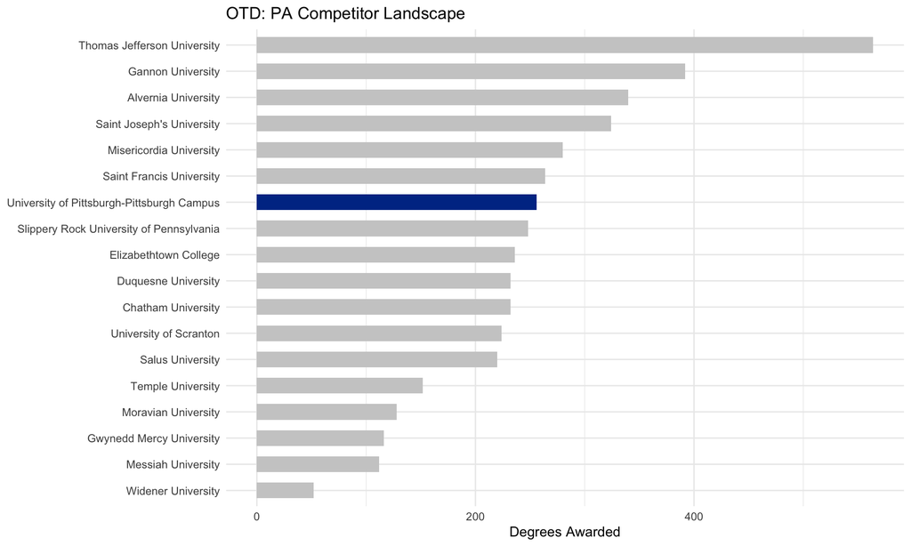

### PAS

| Institution | City | Awards | Degree Levels |
| --- | --- | --- | --- |
| Thomas Jefferson University | Philadelphia | 512 | Doctorate |
| Commonwealth University of Pennsylvania | Bloomsburg | 460 | Doctorate |
| Duquesne University | Pittsburgh | 400 | Doctorate, Masters |
| Arcadia University | Glenside | 388 | Doctorate |
| Saint Francis University | Loretto | 368 | Doctorate, Masters |
| Philadelphia College of Osteopathic Medicine | Philadelphia | 352 | Doctorate |
| Gannon University | Erie | 336 | Doctorate |
| DeSales University | Center Valley | 300 | Doctorate |
| Drexel University | Philadelphia | 288 | Doctorate |
| King’s College | Wilkes-Barre | 272 | Doctorate |
| Chatham University | Pittsburgh | 260 | Doctorate |
| **University of Pittsburgh-Pittsburgh Campus (PITT)** | Pittsburgh | 240 | Doctorate |
| Marywood University | Scranton | 228 | Doctorate |
| Salus University | Elkins Park | 196 | Doctorate |
| Seton Hill University | Greensburg | 144 | Doctorate |
| Slippery Rock University of Pennsylvania | Slippery Rock | 128 | Doctorate |
| Temple University | Philadelphia | 124 | Doctorate |
| Pennsylvania State University-Main Campus | University Park | 120 | Doctorate |
| Mercyhurst University | Erie | 112 | Doctorate |
| Misericordia University | Dallas | 76 | Doctorate |
| Pennsylvania College of Technology | Williamsport | 76 | Doctorate, Masters |

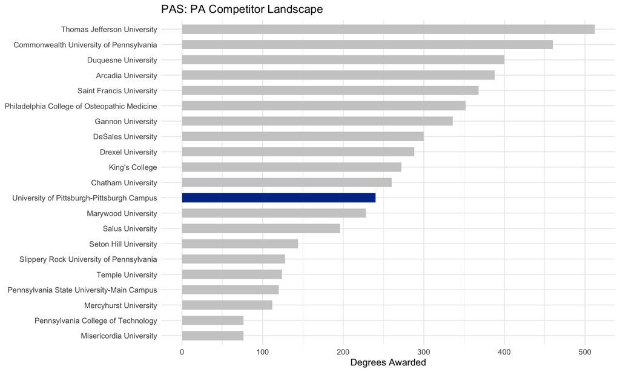

### SLP

| Institution | City | Awards | Degree Levels |
| --- | --- | --- | --- |
| Pennsylvania Western University | California | 504 | Doctorate, Masters |
| **University of Pittsburgh-Pittsburgh Campus (PITT)** | Pittsburgh | 500 | Doctorate, Masters |
| West Chester University of Pennsylvania | West Chester | 452 | Doctorate, Masters |
| Temple University | Philadelphia | 428 | Doctorate, Masters |
| Commonwealth University of Pennsylvania | Bloomsburg | 372 | Doctorate, Masters |
| La Salle University | Philadelphia | 256 | Doctorate, Masters |
| Duquesne University | Pittsburgh | 252 | Doctorate, Masters |
| Indiana University of Pennsylvania-Main Campus | Indiana | 204 | Doctorate, Masters |
| East Stroudsburg University of Pennsylvania | East Stroudsburg | 196 | Doctorate, Masters |
| Marywood University | Scranton | 176 | Doctorate, Masters |
| Misericordia University | Dallas | 156 | Doctorate |
| Salus University | Elkins Park | 144 | Doctorate |
| Lebanon Valley College | Annville | 124 | Doctorate |
| Moravian University | Bethlehem | 100 | Doctorate |
| Thiel College | Greenville | 52 | Doctorate |
| Geneva College | Beaver Falls | 28 | Masters |

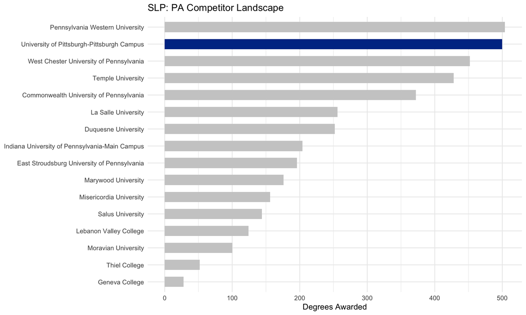

### SS

| Institution | City | Awards | Degree Levels |
| --- | --- | --- | --- |
| Pennsylvania State University-Main Campus | University Park | 752 | Doctorate, Masters |
| Temple University | Philadelphia | 400 | Doctorate, Masters |
| Lebanon Valley College | Annville | 324 | Doctorate, Masters |
| Pennsylvania Western University | California | 296 | Masters, Post-Masters Certificate |
| East Stroudsburg University of Pennsylvania | East Stroudsburg | 264 | Doctorate, Masters |
| Gettysburg College | Gettysburg | 264 | Masters |
| Gannon University | Erie | 252 | Doctorate, Masters |
| University of Scranton | Scranton | 204 | Masters |
| **University of Pittsburgh-Pittsburgh Campus (PITT)** | Pittsburgh | 164 | Doctorate, Masters |
| Shippensburg University of Pennsylvania | Shippensburg | 140 | Masters |
| Ursinus College | Collegeville | 120 | Masters |
| Pennsylvania State University-Penn State Berks | Reading | 104 | Masters |
| Chatham University | Pittsburgh | 100 | Masters |
| King’s College | Wilkes-Barre | 96 | Masters |
| Pennsylvania State University-Penn State Harrisburg | Middletown | 92 | Masters |
| DeSales University | Center Valley | 84 | Masters |
| Chestnut Hill College | Philadelphia | 84 | Masters |
| Grove City College | Grove City | 84 | Masters |
| Seton Hill University | Greensburg | 80 | Masters |
| University of Pittsburgh-Bradford | Bradford | 64 | Masters |
| Cabrini University | Radnor | 60 | Masters |
| Immaculata University | Immaculata | 56 | Masters |
| Cedar Crest College | Allentown | 52 | Doctorate, Masters, Post-Masters Certificate |
| Saint Francis University | Loretto | 44 | Masters |
| Mercyhurst University | Erie | 36 | Masters |
| West Chester University of Pennsylvania | West Chester | 36 | Doctorate |
| Pennsylvania State University-Penn State Altoona | Altoona | 32 | Masters |
| Wilson College | Chambersburg | 32 | Masters |
| Eastern University | Saint Davids | 28 | Masters |
| Thiel College | Greenville | 28 | Masters |
| Commonwealth University of Pennsylvania | Bloomsburg | 20 | Doctorate |
| La Roche University | Pittsburgh | 16 | Masters |
| Marywood University | Scranton | 16 | Masters |
| Saint Joseph’s University | Philadelphia | 12 | Masters |

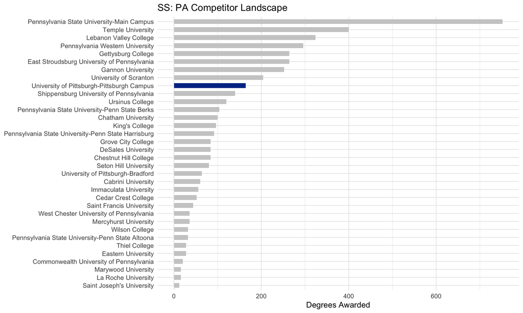

# 2 - Tier 2: Regional Competition (Pittsburgh-Erie Corridor)

The Pittsburgh-Erie corridor covers 17 counties in western and northwestern PA. These are the institutions a local prospective student would most directly weigh against Pitt.

## 2.1 Summary

```r
tier2_summary |>
  arrange(desc(total_grads)) |>
  select(
    Program              = shrs_program,
    `Regional Competitors` = n_competitors,
    `Regional Grads`       = total_grads,
    `Pitt Grads`           = pitt_grads,
    `Pitt Share (%)`       = pitt_share_pct
  ) |>
  kable(format.args = list(big.mark = ",")) |>
  kable_styling(bootstrap_options = c("striped", "hover"), full_width = FALSE)
```

| Program | Regional Competitors | Regional Grads | Pitt Grads | Pitt Share (%) |
| --- | --- | --- | --- | --- |
| PAS | 6 | 1,620 | 240 | 14.8 |
| SLP | 5 | 1,540 | 500 | 32.5 |
| OTD | 4 | 1,360 | 256 | 18.8 |
| DPT | 4 | 1,320 | 272 | 20.6 |
| SS | 8 | 1,056 | 164 | 15.5 |
| AuD | 2 | 756 | 500 | 66.1 |
| AT | 7 | 212 | 0 | 0.0 |
| HIM | 3 | 80 | 8 | 10.0 |
| DN | 1 | 12 | 0 | 0.0 |

## 2.2 Regional Share Visualization

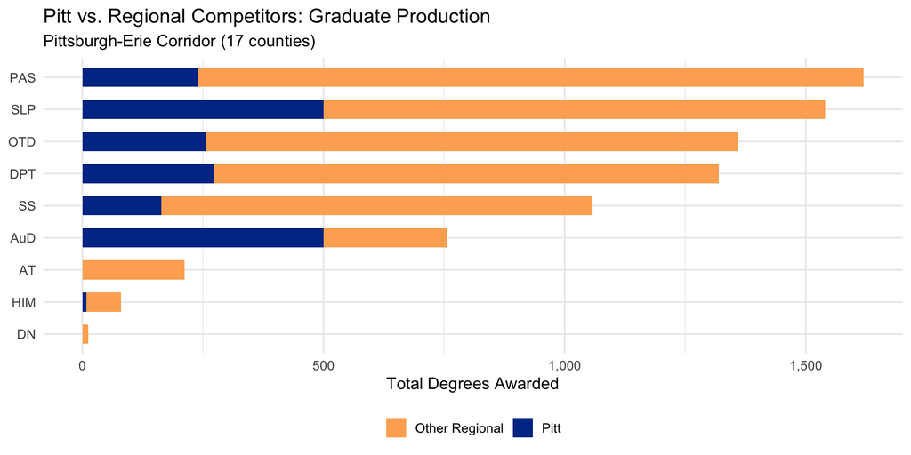

```r
tier2_summary |>
  mutate(other_grads = total_grads - pitt_grads) |>
  select(shrs_program, Pitt = pitt_grads, `Other Regional` = other_grads) |>
  pivot_longer(-shrs_program, names_to = "source", values_to = "grads") |>
  ggplot(aes(x = reorder(shrs_program, grads, sum), y = grads, fill = source)) +
  geom_col(width = 0.6) +
  coord_flip() +
  scale_y_continuous(labels = comma) +
  scale_fill_manual(values = c("Pitt" = "#003594", "Other Regional" = "#FDAE61")) +
  labs(
    title = "Pitt vs. Regional Competitors: Graduate Production",
    subtitle = "Pittsburgh-Erie Corridor (17 counties)",
    x = NULL, y = "Total Degrees Awarded", fill = NULL
  ) +
  theme_minimal(base_size = 13) +
  theme(legend.position = "bottom")
```

## 2.3 Regional Competitor Lists by Program

```r
for (prog in sort(unique(tier2$shrs_program))) {

  cat(paste0("\n### ", prog, "\n\n"))

  prog_data <- tier2 |>
    filter(shrs_program == prog) |>
    mutate(is_pitt = unitid == PITT_UNITID)

  prog_data |>
    mutate(Institution = if_else(is_pitt, paste0("**", inst_name, " (PITT)**"), inst_name)) |>
    select(Institution, City = city, Region = region, Awards = total_awards,
           `Degree Levels` = degree_levels) |>
    kable(format.args = list(big.mark = ",")) |>
    kable_styling(bootstrap_options = c("striped", "hover"), full_width = FALSE) |>
    print()

  cat("\n")
}
```

### AT

| Institution | City | Region | Awards | Degree Levels |
| --- | --- | --- | --- | --- |
| Slippery Rock University of Pennsylvania | Slippery Rock | Pittsburgh Metro | 44 | Doctorate |
| Waynesburg University | Waynesburg | Pittsburgh Metro | 44 | Doctorate, Masters |
| Mercyhurst University | Erie | Erie Area | 36 | Masters |
| Duquesne University | Pittsburgh | Pittsburgh Metro | 28 | Masters |
| Gannon University | Erie | Erie Area | 28 | Doctorate |
| Chatham University | Pittsburgh | Pittsburgh Metro | 16 | Doctorate |
| Pennsylvania Western University | California | Pittsburgh Metro | 16 | Doctorate |

### AuD

| Institution | City | Region | Awards | Degree Levels |
| --- | --- | --- | --- | --- |
| **University of Pittsburgh-Pittsburgh Campus (PITT)** | Pittsburgh | Pittsburgh Metro | 500 | Doctorate, Masters |
| Indiana University of Pennsylvania-Main Campus | Indiana | Surrounding | 204 | Doctorate, Masters |
| Thiel College | Greenville | I-79 Corridor | 52 | Doctorate |

### DN

| Institution | City | Region | Awards | Degree Levels |
| --- | --- | --- | --- | --- |
| Seton Hill University | Greensburg | Pittsburgh Metro | 12 | Masters |

### DPT

| Institution | City | Region | Awards | Degree Levels |
| --- | --- | --- | --- | --- |
| Duquesne University | Pittsburgh | Pittsburgh Metro | 368 | Doctorate, Masters |
| Gannon University | Erie | Erie Area | 308 | Doctorate |
| **University of Pittsburgh-Pittsburgh Campus (PITT)** | Pittsburgh | Pittsburgh Metro | 272 | Doctorate |
| Slippery Rock University of Pennsylvania | Slippery Rock | Pittsburgh Metro | 192 | Doctorate |
| Chatham University | Pittsburgh | Pittsburgh Metro | 180 | Doctorate |

### HIM

| Institution | City | Region | Awards | Degree Levels |
| --- | --- | --- | --- | --- |
| Carlow University | Pittsburgh | Pittsburgh Metro | 28 | Masters |
| Slippery Rock University of Pennsylvania | Slippery Rock | Pittsburgh Metro | 24 | Doctorate |
| Duquesne University | Pittsburgh | Pittsburgh Metro | 20 | Masters |
| **University of Pittsburgh-Pittsburgh Campus (PITT)** | Pittsburgh | Pittsburgh Metro | 8 | Masters |

### OTD

| Institution | City | Region | Awards | Degree Levels |
| --- | --- | --- | --- | --- |
| Gannon University | Erie | Erie Area | 392 | Doctorate |
| **University of Pittsburgh-Pittsburgh Campus (PITT)** | Pittsburgh | Pittsburgh Metro | 256 | Doctorate, Post-Masters Certificate |
| Slippery Rock University of Pennsylvania | Slippery Rock | Pittsburgh Metro | 248 | Doctorate |
| Chatham University | Pittsburgh | Pittsburgh Metro | 232 | Doctorate |
| Duquesne University | Pittsburgh | Pittsburgh Metro | 232 | Doctorate, Masters |

### PAS

| Institution | City | Region | Awards | Degree Levels |
| --- | --- | --- | --- | --- |
| Duquesne University | Pittsburgh | Pittsburgh Metro | 400 | Doctorate, Masters |
| Gannon University | Erie | Erie Area | 336 | Doctorate |
| Chatham University | Pittsburgh | Pittsburgh Metro | 260 | Doctorate |
| **University of Pittsburgh-Pittsburgh Campus (PITT)** | Pittsburgh | Pittsburgh Metro | 240 | Doctorate |
| Seton Hill University | Greensburg | Pittsburgh Metro | 144 | Doctorate |
| Slippery Rock University of Pennsylvania | Slippery Rock | Pittsburgh Metro | 128 | Doctorate |
| Mercyhurst University | Erie | Erie Area | 112 | Doctorate |

### SLP

| Institution | City | Region | Awards | Degree Levels |
| --- | --- | --- | --- | --- |
| Pennsylvania Western University | California | Pittsburgh Metro | 504 | Doctorate, Masters |
| **University of Pittsburgh-Pittsburgh Campus (PITT)** | Pittsburgh | Pittsburgh Metro | 500 | Doctorate, Masters |
| Duquesne University | Pittsburgh | Pittsburgh Metro | 252 | Doctorate, Masters |
| Indiana University of Pennsylvania-Main Campus | Indiana | Surrounding | 204 | Doctorate, Masters |
| Thiel College | Greenville | I-79 Corridor | 52 | Doctorate |
| Geneva College | Beaver Falls | Pittsburgh Metro | 28 | Masters |

### SS

| Institution | City | Region | Awards | Degree Levels |
| --- | --- | --- | --- | --- |
| Pennsylvania Western University | California | Pittsburgh Metro | 296 | Masters, Post-Masters Certificate |
| Gannon University | Erie | Erie Area | 252 | Doctorate, Masters |
| **University of Pittsburgh-Pittsburgh Campus (PITT)** | Pittsburgh | Pittsburgh Metro | 164 | Doctorate, Masters |
| Chatham University | Pittsburgh | Pittsburgh Metro | 100 | Masters |
| Grove City College | Grove City | I-79 Corridor | 84 | Masters |
| Seton Hill University | Greensburg | Pittsburgh Metro | 80 | Masters |
| Mercyhurst University | Erie | Erie Area | 36 | Masters |
| Thiel College | Greenville | I-79 Corridor | 28 | Masters |
| La Roche University | Pittsburgh | Pittsburgh Metro | 16 | Masters |

# 3 - Cross-Program Analysis

## 3.1 Most Frequent Competitors

Which PA institutions compete with Pitt across the most programs?

```r
master_roster |>
  filter(!is_pitt) |>
  group_by(unitid, inst_name, city) |>
  summarise(
    n_programs   = n(),
    programs     = paste(sort(unique(shrs_program)), collapse = ", "),
    total_awards = sum(total_awards, na.rm = TRUE),
    .groups      = "drop"
  ) |>
  arrange(desc(n_programs), desc(total_awards)) |>
  head(20) |>
  select(
    Institution  = inst_name,
    City         = city,
    `# Programs` = n_programs,
    Programs     = programs,
    `Total Awards` = total_awards
  ) |>
  kable(format.args = list(big.mark = ",")) |>
  kable_styling(bootstrap_options = c("striped", "hover"), full_width = FALSE)
```

| Institution | City | # Programs | Programs | Total Awards |
| --- | --- | --- | --- | --- |
| Temple University | Philadelphia | 7 | AT, AuD, DPT, OTD, PAS, SLP, SS | 1,820 |
| Duquesne University | Pittsburgh | 6 | AT, DPT, HIM, OTD, PAS, SLP | 1,300 |
| Marywood University | Scranton | 6 | AT, AuD, DN, PAS, SLP, SS | 652 |
| West Chester University of Pennsylvania | West Chester | 5 | AT, AuD, DN, SLP, SS | 1,472 |
| Gannon University | Erie | 5 | AT, DPT, OTD, PAS, SS | 1,316 |
| Commonwealth University of Pennsylvania | Bloomsburg | 5 | AT, AuD, PAS, SLP, SS | 1,184 |
| Chatham University | Pittsburgh | 5 | AT, DPT, OTD, PAS, SS | 788 |
| Slippery Rock University of Pennsylvania | Slippery Rock | 5 | AT, DPT, HIM, OTD, PAS | 636 |
| Thomas Jefferson University | Philadelphia | 4 | AT, DPT, OTD, PAS | 1,352 |
| Saint Francis University | Loretto | 4 | DPT, OTD, PAS, SS | 832 |
| Salus University | Elkins Park | 4 | AuD, OTD, PAS, SLP | 792 |
| Misericordia University | Dallas | 4 | DPT, OTD, PAS, SLP | 700 |
| Lebanon Valley College | Annville | 4 | AT, DPT, SLP, SS | 668 |
| Messiah University | Mechanicsburg | 4 | AT, DN, DPT, OTD | 356 |
| Pennsylvania State University-Main Campus | University Park | 3 | AT, PAS, SS | 932 |
| Pennsylvania Western University | California | 3 | AT, SLP, SS | 816 |
| East Stroudsburg University of Pennsylvania | East Stroudsburg | 3 | AT, SLP, SS | 720 |
| University of Scranton | Scranton | 3 | DPT, OTD, SS | 708 |
| Saint Joseph’s University | Philadelphia | 3 | DPT, OTD, SS | 596 |
| Drexel University | Philadelphia | 3 | DN, DPT, PAS | 588 |

## 3.2 Competition Intensity by Program

How crowded is each program’s competitive landscape?

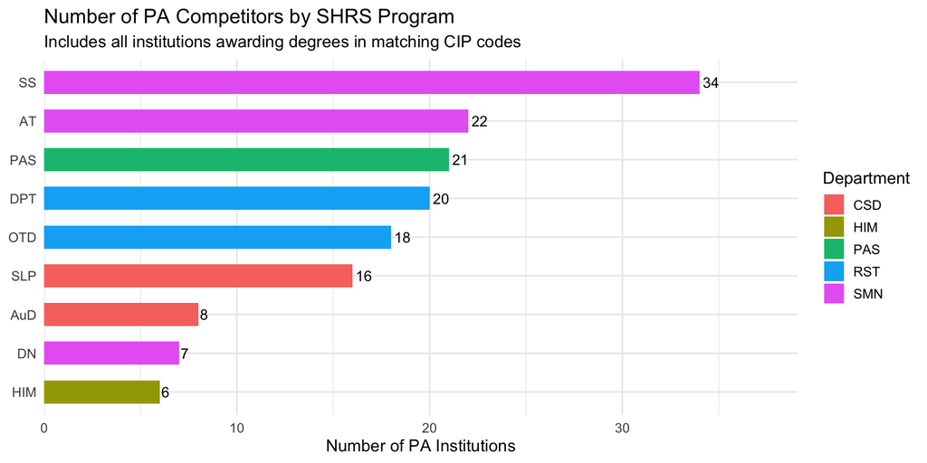

```r
tier1_summary |>
  ggplot(aes(x = reorder(shrs_program, n_competitors),
             y = n_competitors, fill = shrs_dept)) +
  geom_col(width = 0.6) +
  geom_text(aes(label = n_competitors), hjust = -0.2, size = 4) +
  coord_flip() +
  scale_y_continuous(expand = expansion(mult = c(0, 0.15))) +
  labs(
    title = "Number of PA Competitors by SHRS Program",
    subtitle = "Includes all institutions awarding degrees in matching CIP codes",
    x = NULL, y = "Number of PA Institutions", fill = "Department"
  ) +
  theme_minimal(base_size = 13)
```

## 3.3 Pitt’s Position: Percentile by Program

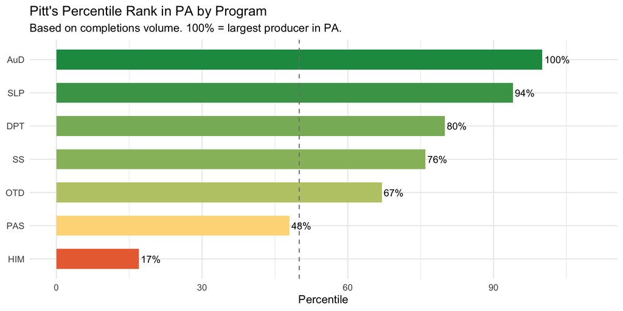

```r
pitt_rank |>
  ggplot(aes(x = reorder(shrs_program, percentile), y = percentile,
             fill = percentile)) +
  geom_col(width = 0.6) +
  geom_text(aes(label = paste0(percentile, "%")), hjust = -0.1, size = 4) +
  geom_hline(yintercept = 50, linetype = "dashed", color = "gray50") +
  coord_flip() +
  scale_y_continuous(limits = c(0, 110)) +
  scale_fill_gradient2(low = "#d7191c", mid = "#fee08b", high = "#1a9850",
                       midpoint = 50, guide = "none") +
  labs(
    title = "Pitt's Percentile Rank in PA by Program",
    subtitle = "Based on completions volume. 100% = largest producer in PA.",
    x = NULL, y = "Percentile"
  ) +
  theme_minimal(base_size = 13)
```

# 4 - Tier 1 vs. Tier 2 Comparison

How does the competitive picture change when we zoom from statewide to regional?

```r
comparison <- tier1_summary |>
  select(shrs_program,
         t1_schools = n_competitors,
         t1_grads   = total_pa_graduates,
         t1_pitt    = pitt_share_pct) |>
  left_join(
    tier2_summary |>
      select(shrs_program,
             t2_schools = n_competitors,
             t2_grads   = total_grads,
             t2_pitt    = pitt_share_pct),
    by = "shrs_program"
  ) |>
  mutate(
    share_increase = round(t2_pitt - t1_pitt, 1)
  )

comparison |>
  select(
    Program               = shrs_program,
    `PA Schools`          = t1_schools,
    `Regional Schools`    = t2_schools,
    `Pitt Share PA (%)`   = t1_pitt,
    `Pitt Share Reg (%)` = t2_pitt,
    `Share Increase (pp)` = share_increase
  ) |>
  kable() |>
  kable_styling(bootstrap_options = c("striped", "hover"), full_width = FALSE)
```

| Program | PA Schools | Regional Schools | Pitt Share PA (%) | Pitt Share Reg (%) | Share Increase (pp) |
| --- | --- | --- | --- | --- | --- |
| AT | 22 | 7 | 0.0 | 0.0 | 0.0 |
| AuD | 8 | 2 | 21.4 | 66.1 | 44.7 |
| DN | 7 | 1 | 0.0 | 0.0 | 0.0 |
| DPT | 20 | 4 | 5.5 | 20.6 | 15.1 |
| HIM | 6 | 3 | 6.1 | 10.0 | 3.9 |
| OTD | 18 | 4 | 5.9 | 18.8 | 12.9 |
| PAS | 21 | 6 | 4.5 | 14.8 | 10.3 |
| SLP | 16 | 5 | 12.7 | 32.5 | 19.8 |
| SS | 34 | 8 | 3.7 | 15.5 | 11.8 |

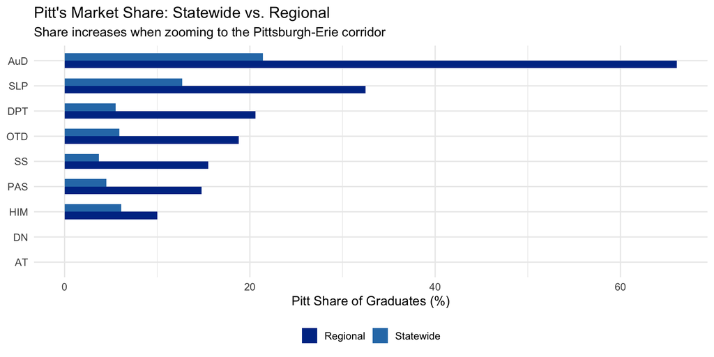

```r
comparison |>
  select(shrs_program, `Statewide` = t1_pitt, `Regional` = t2_pitt) |>
  pivot_longer(-shrs_program, names_to = "scope", values_to = "pitt_share") |>
  ggplot(aes(x = reorder(shrs_program, pitt_share, max),
             y = pitt_share, fill = scope)) +
  geom_col(position = "dodge", width = 0.6) +
  coord_flip() +
  scale_fill_manual(values = c("Statewide" = "#2c7bb6", "Regional" = "#003594")) +
  labs(
    title = "Pitt's Market Share: Statewide vs. Regional",
    subtitle = "Share increases when zooming to the Pittsburgh-Erie corridor",
    x = NULL, y = "Pitt Share of Graduates (%)", fill = NULL
  ) +
  theme_minimal(base_size = 13) +
  theme(legend.position = "bottom")
```

# 5 - Key Takeaways

```r
cat("## Headline Findings\n\n")
```

## Headline Findings

```r
# Strongest positions
strong <- pitt_rank |> filter(percentile >= 75) |> arrange(desc(percentile))
if (nrow(strong) > 0) {
  cat("**Strongest competitive positions** (75th+ percentile in PA):\n\n")
  for (i in seq_len(nrow(strong))) {
    cat(paste0("- **", strong$shrs_program[i], "**: Rank ",
               strong$rank[i], " of ", strong$n_schools[i],
               " (", strong$percentile[i], "th percentile, ",
               strong$total_awards[i], " awards)\n"))
  }
  cat("\n")
}
```

**Strongest competitive positions** (75th+ percentile in PA):

- **AuD**: Rank 1 of 8 (100th percentile, 500 awards)
- **SLP**: Rank 2 of 16 (94th percentile, 500 awards)
- **DPT**: Rank 5 of 20 (80th percentile, 272 awards)
- **SS**: Rank 9 of 34 (76th percentile, 164 awards)

```r
# Weaker positions
weak <- pitt_rank |> filter(percentile < 50) |> arrange(percentile)
if (nrow(weak) > 0) {
  cat("**Areas for attention** (below 50th percentile in PA):\n\n")
  for (i in seq_len(nrow(weak))) {
    cat(paste0("- **", weak$shrs_program[i], "**: Rank ",
               weak$rank[i], " of ", weak$n_schools[i],
               " (", weak$percentile[i], "th percentile, ",
               weak$total_awards[i], " awards)\n"))
  }
  cat("\n")
}
```

**Areas for attention** (below 50th percentile in PA):

- **HIM**: Rank 6 of 6 (17th percentile, 8 awards)
- **PAS**: Rank 12 of 21 (48th percentile, 240 awards)

```r
# Missing from ranking
missing <- setdiff(sort(unique(tier1$shrs_program)), pitt_rank$shrs_program)
if (length(missing) > 0) {
  cat("**Programs where Pitt shows 0 IPEDS completions**: ",
      paste(missing, collapse = ", "),
      ". These may be coded under different CIP codes in IPEDS or may not currently be awarding degrees.\n\n")
}
```

**Programs where Pitt shows 0 IPEDS completions**: AT, DN . These may be coded under different CIP codes in IPEDS or may not currently be awarding degrees.

```r
# Most competitive markets
crowded <- tier1_summary |> arrange(desc(n_competitors)) |> head(3)
cat("**Most crowded PA markets**: ",
    paste0(crowded$shrs_program, " (", crowded$n_competitors, " schools)"),
    sep = "", collapse = ", ")
```

**Most crowded PA markets**: SS (34 schools)AT (22 schools)PAS (21 schools),

```r
cat("\n\n")
```

```r
# Regional dominance
reg_strong <- tier2_summary |> filter(pitt_share_pct >= 30) |> arrange(desc(pitt_share_pct))
if (nrow(reg_strong) > 0) {
  cat("**Regional dominance** (30%+ share in Pittsburgh-Erie corridor):\n\n")
  for (i in seq_len(nrow(reg_strong))) {
    cat(paste0("- **", reg_strong$shrs_program[i], "**: ",
               reg_strong$pitt_share_pct[i], "% regional share\n"))
  }
}
```

**Regional dominance** (30%+ share in Pittsburgh-Erie corridor):

- **AuD**: 66.1% regional share
- **SLP**: 32.5% regional share

# Appendix

**Data Source**: IPEDS Completions by 6-digit CIP code, accessed via Urban Institute Education Data Portal API. Institution directory from the same source.

**Tier Definitions**:

- Tier 1 (Statewide): All PA institutions with non-zero completions in target CIP codes
- Tier 2 (Regional): Tier 1 subset in 17 counties from Pittsburgh metro through Erie
- Tier 3 (National): U.S. News top programs (not yet populated)

**Latest IPEDS Year**: 2022

**Note on AT and DN**: Pitt may show 0 completions for Athletic Training and Dietetics/Nutrition if these programs are coded under different CIP codes in Pitt’s IPEDS reporting. Verify with SHRS registrar.